# InVivoStat Correlation Analysis

## Responses

This module assesses the correlation between the response variables Resp25, Resp30 and Resp31.

## Non-categorised results

### Scatterplots of the observed data

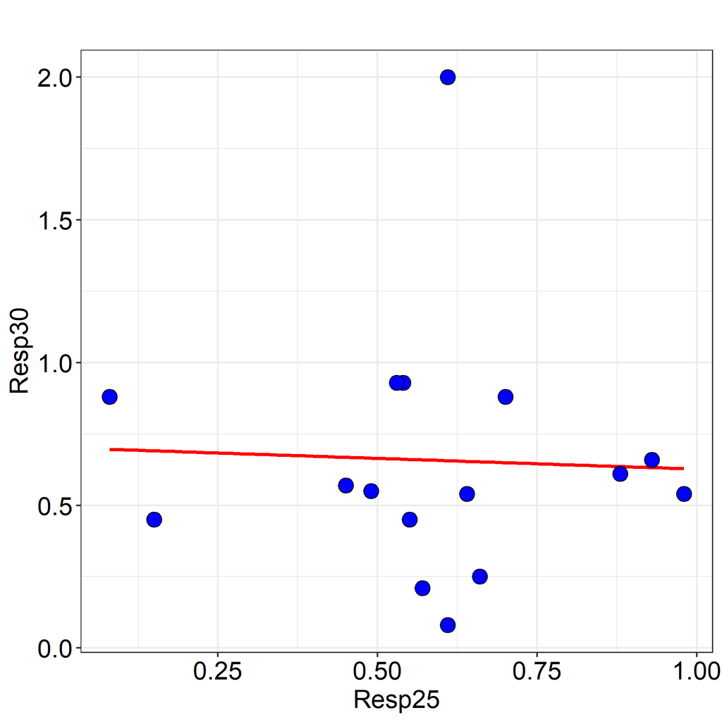

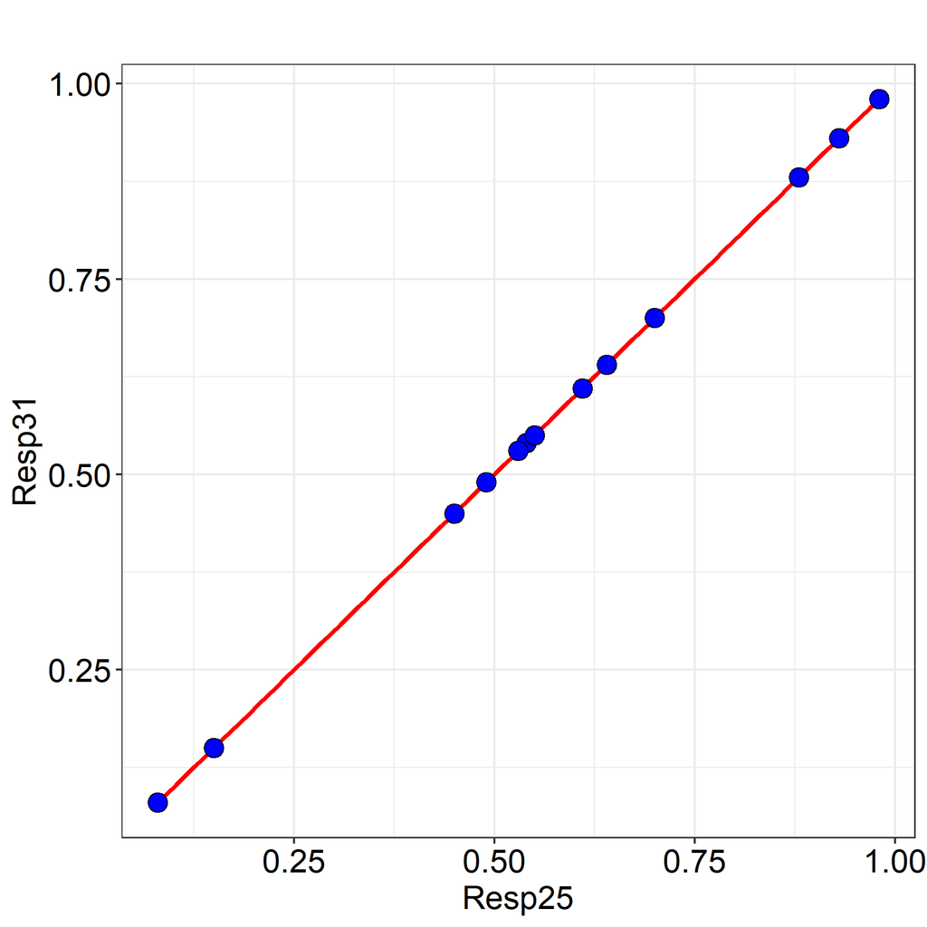

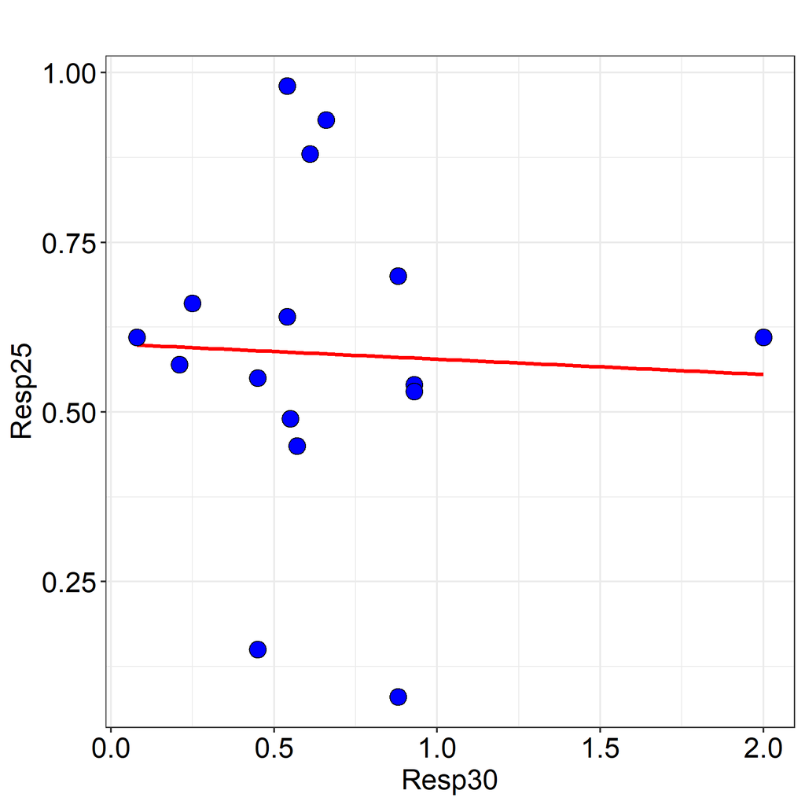

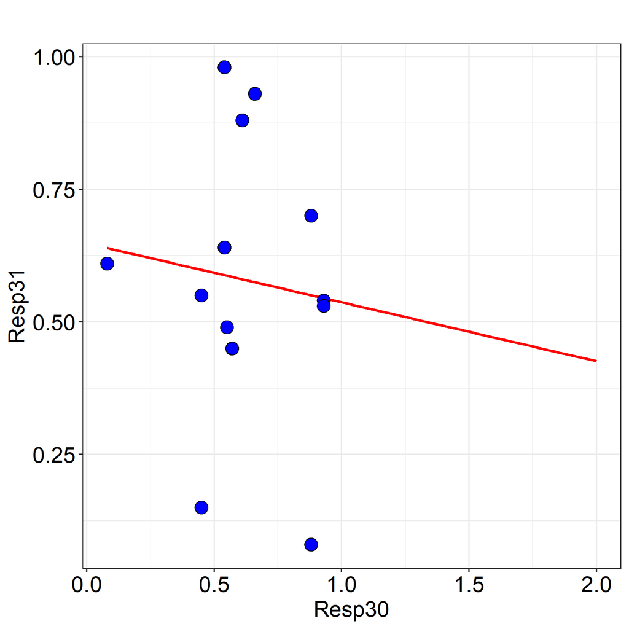

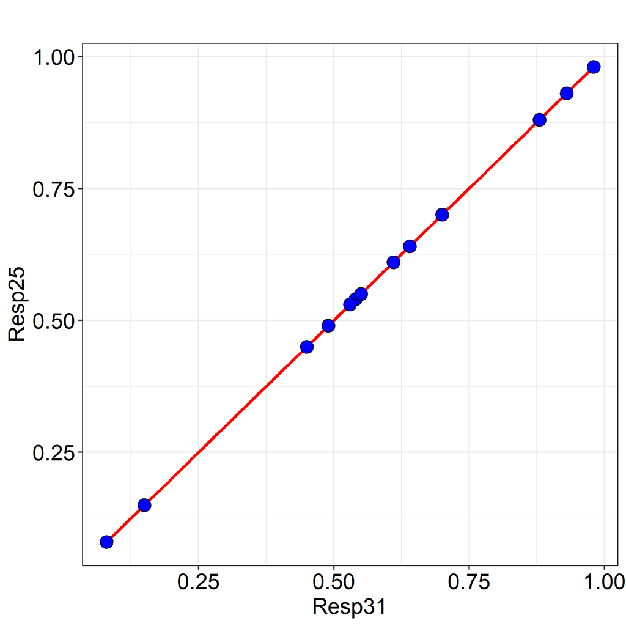

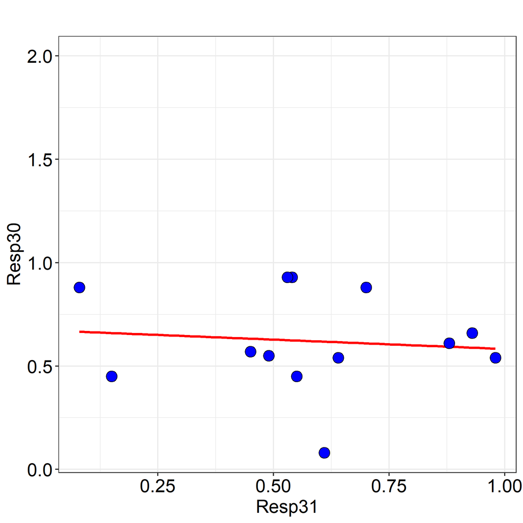

### Matrixplot, including linear regression lines

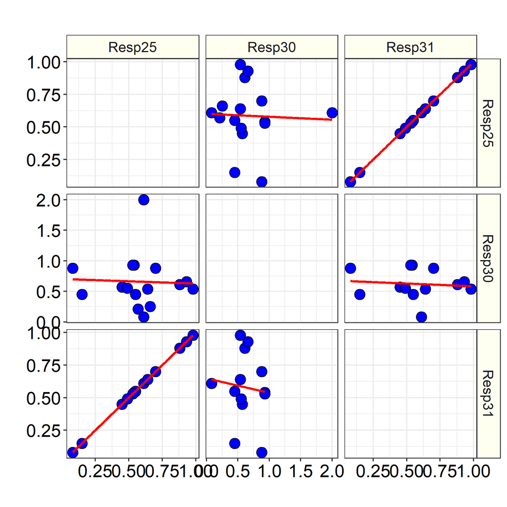

### Table of results for the one-sided (greater than) Pearson's product moment correlation coefficient

| Correlation | First variable |  | Second variable | n | Correlation Coefficient | Test statistic | p-value |
| --- | --- | --- | --- | --- | --- | --- | --- |
| 1 | Resp25 | vs. | Resp30 | 16 | -0.041 | -0.155 | 0.5604 |
| 2 | Resp25 | vs. | Resp31 | 13 | 1.000 | 157384236.665 | < 0.0001 |
| 3 | Resp30 | vs. | Resp31 | 13 | -0.100 | -0.335 | 0.6280 |

### Matrix table of correlation coefficients

|  | Resp25 | Resp30 | Resp31 |
| --- | --- | --- | --- |
| Resp25 | 1 | -0.041 | 1.000 |
| Resp30 | -0.041 | 1 | -0.100 |
| Resp31 | 1.000 | -0.100 | 1 |

### Matrix table of p-values

|  | Resp25 | Resp30 | Resp31 |
| --- | --- | --- | --- |
| Resp25 |  | 0.5604 | < 0.0001 |
| Resp30 | 0.5604 |  | 0.6280 |
| Resp31 | < 0.0001 | 0.6280 |  |

### Matrix table of sample sizes

|  | Resp25 | Resp30 | Resp31 |
| --- | --- | --- | --- |
| Resp25 |  | 16 | 13 |
| Resp30 | 16 |  | 13 |
| Resp31 | 13 | 13 |  |

Conclusion: The following pairwise correlation is statistically significantly at the 1% level: Resp25 vs. Resp31.

## Categorised results

### Categorised scatterplots of the observed data

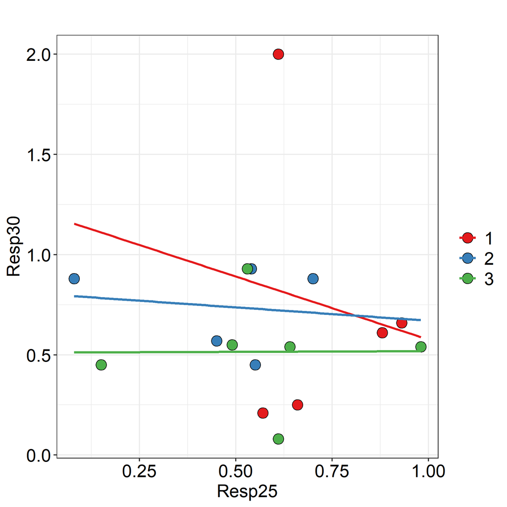

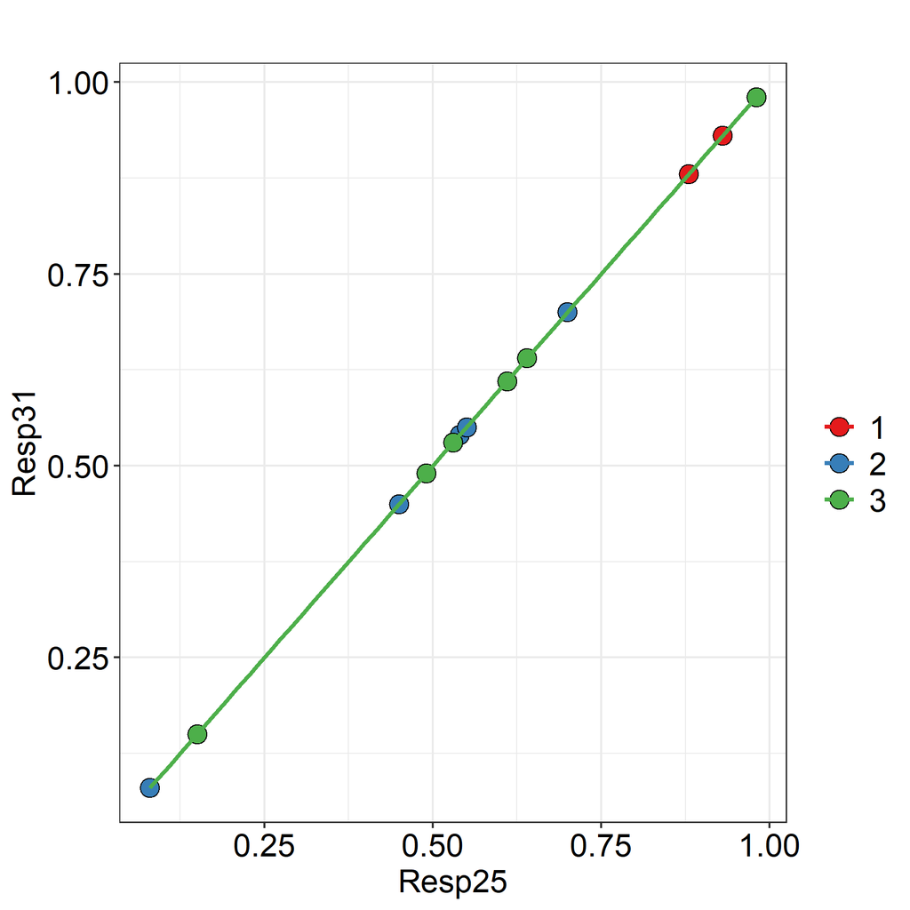

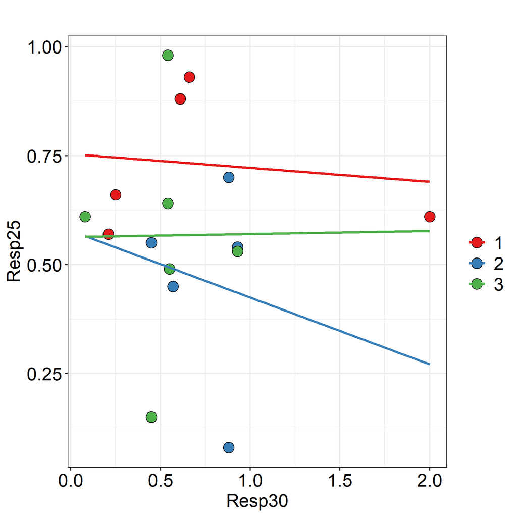

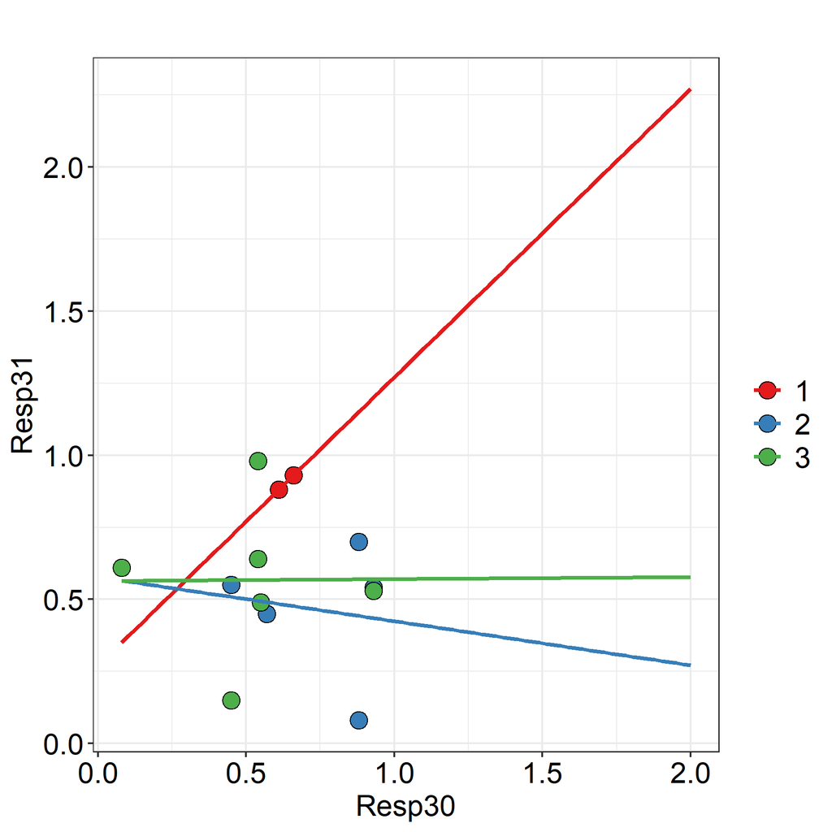

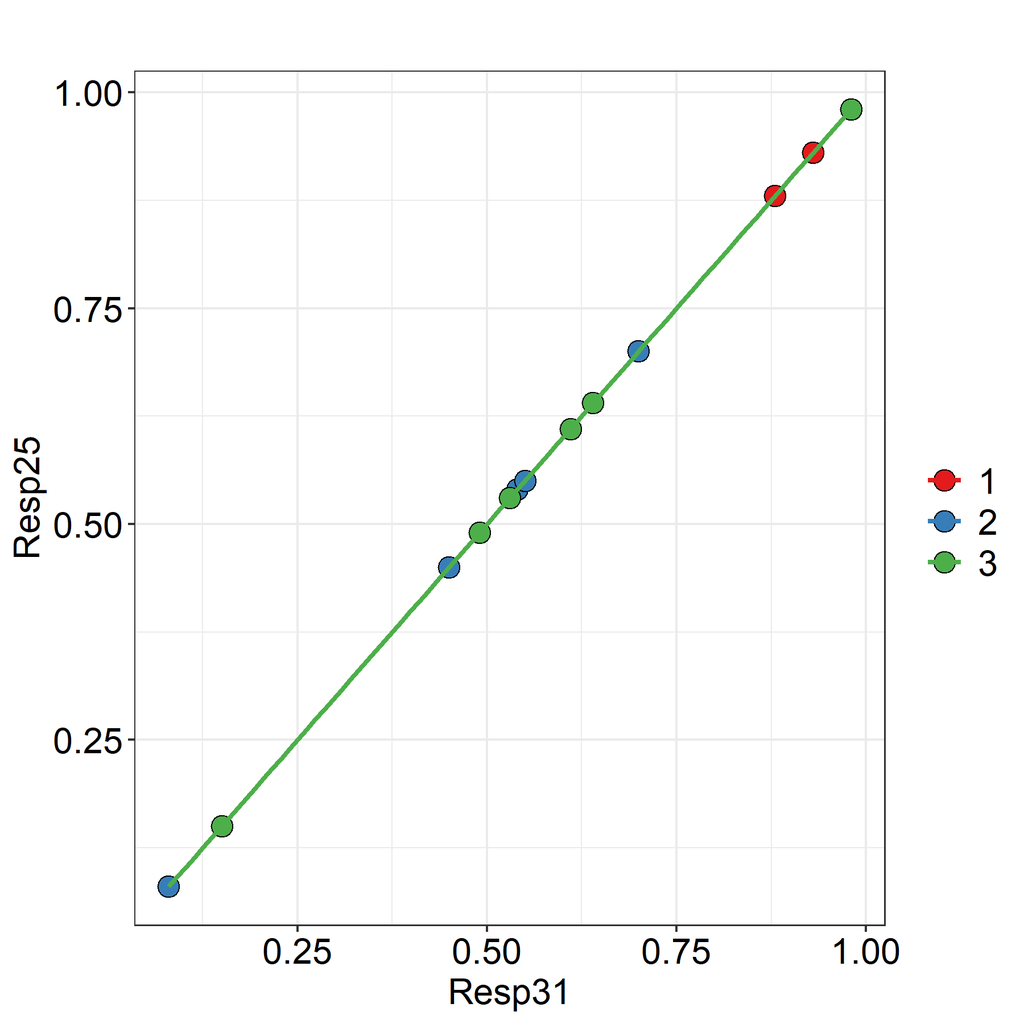

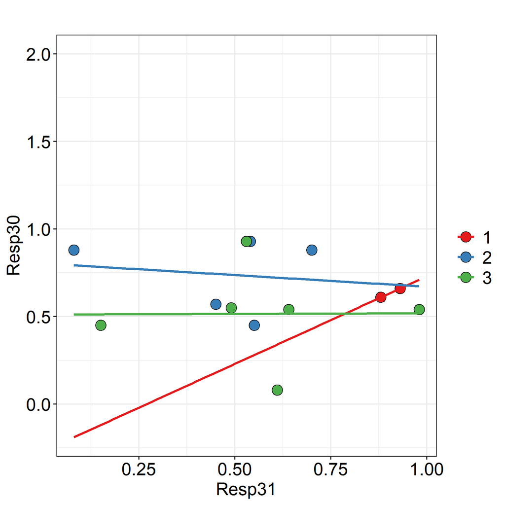

### Categorised matrixplot, including linear regression lines

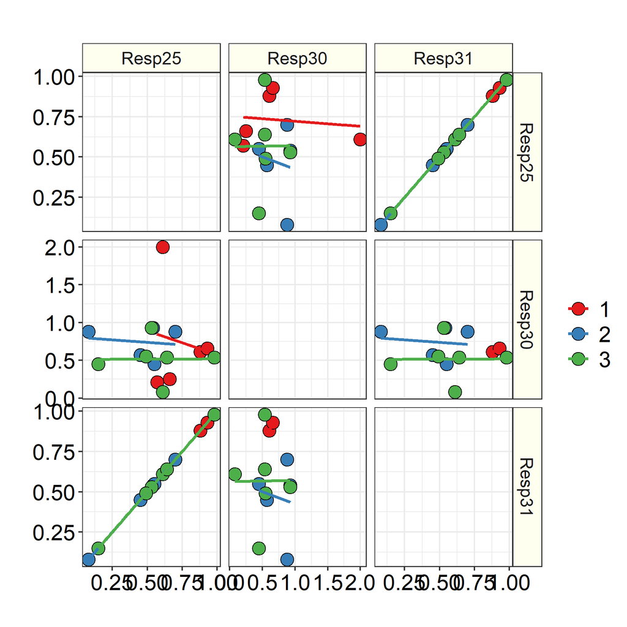

### Table of results for the one-sided (greater than) Pearson's product moment correlation coefficient

| Correlation | Categorisation factor | First variable |  | Second variable | n | Correlation Coefficient | Test statistic | p-value |
| --- | --- | --- | --- | --- | --- | --- | --- | --- |
| 1 | 1 | Resp25 | vs. | Resp30 | 5 | -0.141 | -0.247 | 0.5896 |
| 2 | 2 | Resp25 | vs. | Resp30 | 5 | -0.143 | -0.250 | 0.5906 |
| 3 | 2 | Resp25 | vs. | Resp31 | 5 | 1.000 | Inf | < 0.0001 |
| 4 | 2 | Resp30 | vs. | Resp31 | 5 | -0.143 | -0.250 | 0.5906 |
| 5 | 3 | Resp25 | vs. | Resp30 | 6 | 0.007 | 0.014 | 0.4948 |
| 6 | 3 | Resp25 | vs. | Resp31 | 6 | 1.000 | Inf | < 0.0001 |
| 7 | 3 | Resp30 | vs. | Resp31 | 6 | 0.007 | 0.014 | 0.4948 |

### Matrix table of correlation coefficients

| Categorisation factor |  | Resp25 | Resp30 | Resp31 |
| --- | --- | --- | --- | --- |
| 1 | Resp25 | 1 | -0.141 |  |
| 1 | Resp30 | -0.141 | 1 |  |
| 1 | Resp31 |  |  | 1 |
| 2 | Resp25 | 1 | -0.143 | 1.000 |
| 2 | Resp30 | -0.143 | 1 | -0.143 |
| 2 | Resp31 | 1.000 | -0.143 | 1 |
| 3 | Resp25 | 1 | 0.007 | 1.000 |
| 3 | Resp30 | 0.007 | 1 | 0.007 |
| 3 | Resp31 | 1.000 | 0.007 | 1 |

### Matrix table of p-values

| Categorisation factor |  | Resp25 | Resp30 | Resp31 |
| --- | --- | --- | --- | --- |
| 1 | Resp25 |  | 0.5896 |  |
| 1 | Resp30 | 0.5896 |  |  |
| 1 | Resp31 |  |  |  |
| 2 | Resp25 |  | 0.5906 | < 0.0001 |
| 2 | Resp30 | 0.5906 |  | 0.5906 |
| 2 | Resp31 | < 0.0001 | 0.5906 |  |
| 3 | Resp25 |  | 0.4948 | < 0.0001 |
| 3 | Resp30 | 0.4948 |  | 0.4948 |
| 3 | Resp31 | < 0.0001 | 0.4948 |  |

### Matrix table of sample sizes

| Categorisation factor |  | Resp25 | Resp30 | Resp31 |
| --- | --- | --- | --- | --- |
| 1 | Resp25 |  | 5 |  |
| 1 | Resp30 | 5 |  |  |
| 1 | Resp31 |  |  |  |
| 2 | Resp25 |  | 5 | 5 |
| 2 | Resp30 | 5 |  | 5 |
| 2 | Resp31 | 5 | 5 |  |
| 3 | Resp25 |  | 6 | 6 |
| 3 | Resp30 | 6 |  | 6 |
| 3 | Resp31 | 6 | 6 |  |

Conclusion: The following pairwise correlations are statistically significantly at the 1% level: Resp25 vs. Resp31 (categorisation factor(s) level 2), Resp25 vs. Resp31 (categorisation factor(s) level 3).

Note that there is only one or two pairs of responses available for one or more of the level(s) of the categorisation factor(s) and hence no correlation analysis can be performed for these level(s) of the categorisation factor(s).

## Analysis description

The test statistic is based on Pearson's product moment correlation coefficient cor(x, y) and follows a t distribution with length(x)-2 degrees of freedom if the samples follow independent normal distributions, see Snedecor and Cochran (1989).

For more information on the theoretical approaches that are implemented within this module, see Bate and Clark (2014).

## References

When referring to InVivoStat, please cite 'InVivoStat, version 5.2.0'.

Bate, S.T. and Clark, R.A. (2014). The Design and Statistical Analysis of Animal Experiments. Cambridge University Press.

Snedecor, G.W. and Cochran, W.G. (1989). Statistical Methods. 8th edition; Iowa State University Press, Iowa, USA.